# Statistik och dataanalys I, 15 hp

Inlämningsuppgift 2, 1.5 hp

Authors

Publicerad

March 10, 2023

**Inlämning**

Inlämningsuppgiften ska lämnas in i form av ett html dokument genererat av det här Quarto-dokumentet. Öppna upp code chunks under de uppgifter de behövs.

**Kontrollera noga att du inte har några felmeddelande och att dokumentet kompileras utan problem**. Använd tydliga figurer och namnge axlarna med tydliga variabelnamn. Glöm inte att skriva era namn ovanför istället för Namn 1, Namn 2 och Namn 3.

**Matematiska symboler i rapporten**

Om en formel ska anges så är det ok att skriva det i vanlig text (markdown), typ

xbar +- t(0.025,n-1)*s/sqrt(n),

Vill man vara lite fancy kan man ge sig på att skriva matematik med LaTeX genom att använda dubbla dollar-tecken:

$\bar x \pm t_{0.025,n-1}\frac{s}{\sqrt n}$.

LaTeX är fint, men lite krångligt att lära sig hur man ska skriva.

Läs in dina paket här:

och definiera vår dataframe `df` med datamaterialet:

```r
df = electricitycost
head(df)
```

```
  cost rooms people income onlysecondary waterheat cookel poolfilt airrev
1  545     7      4  29900             0         0      1        0      1
2  389     7      2  11700             0         0      1        0      0
3  390     8      2  16900             0         0      0        0      0
4  268     7      2   9750             1         0      1        0      1
5  543     6      2  24700             1         0      0        0      1
6  278     6      3   8450             1         0      0        0      0
  aircond microwave dish dryer
1       1         0    0     0
2       0         1    1     0
3       1         0    0     0
4       1         0    0     1
5       1         1    0     1
6       0         0    0     1
```

## 1. Poisson-modell för antal personer i hushållet

#### 💪 Uppgift 1.1

Vi skattar lambda genom att ta medelvärdet av observerade data, och gör en modell av people från en Pois(lambda)-fördelning.

```r
extrapeople = df$people - 1
lambda <- mean(extrapeople)
xvalues <- 0:5
pois_probs <- dpois(x = xvalues, lambda)
```

#### 💪 Uppgift 1.2

Vi ritar stapeldiagram för observerade data, och för poisson-distributionen.

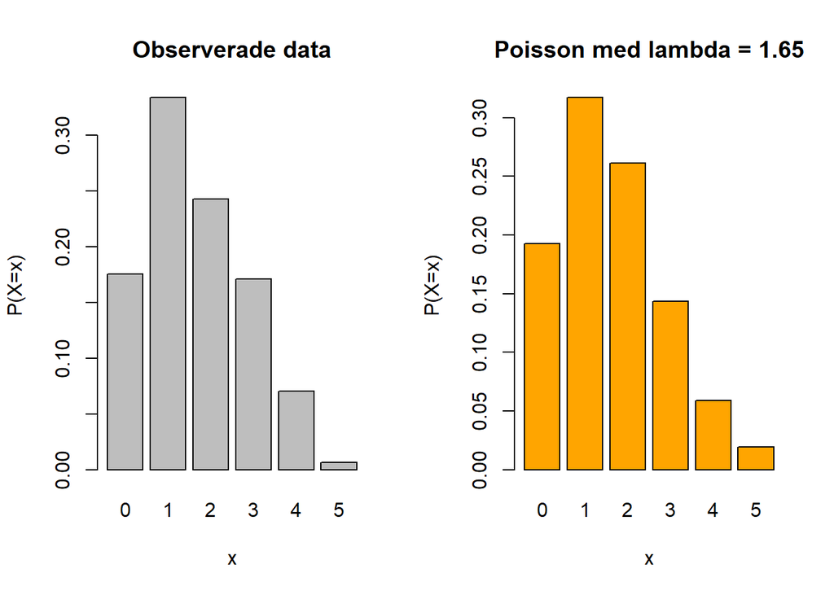

```r
names(pois_probs) <- xvalues
observed <- tally(extrapeople, format = "proportion")
par(mfrow = c(1, 2))
barplot(observed, xlab  = "x", ylab = "P(X=x)", main = "Observerade data")
barplot(pois_probs, col = "orange", xlab  = "x", ylab = "P(X=x)", main = "Poisson med lambda = 1.65")
```

```r
par(mfrow = c(1, 1))
```

Vi ser att diagrammen är lika, och drar slutsatsen att den skattade Poisson-modellen skattar datan väl.

#### 💪 Uppgift 1.3

Vi vill beräkna sannolikheten att att hushåll har fler än 4 personer. I R gör vi beräkningen:

```r
1 - ppois(4, lambda = lambda)
```

```
[1] 0.02631038
```

#### 💪 Uppgift 1.4

Vi vet att variansen och väntevärdet för Poisson-fördelningen är 1.65. Variansen och väntevärdet för observerade datan fås från beräkningarna:

```r
observed_variance <- var(extrapeople)
observed_expected_value <- weighted.mean(extrapeople)
```

vilket ger oss observerad varians = 1.43, och observerat väntevärde = 1.646.

Det observerade väntevärdet är ungefär samma som väntevärdet för Poisson-fördelningen. Den observerade variansen skiljer sig dock. Frågan är om skillnaden är för stor för att Poisson-fördelningen ska vara en bra modell.

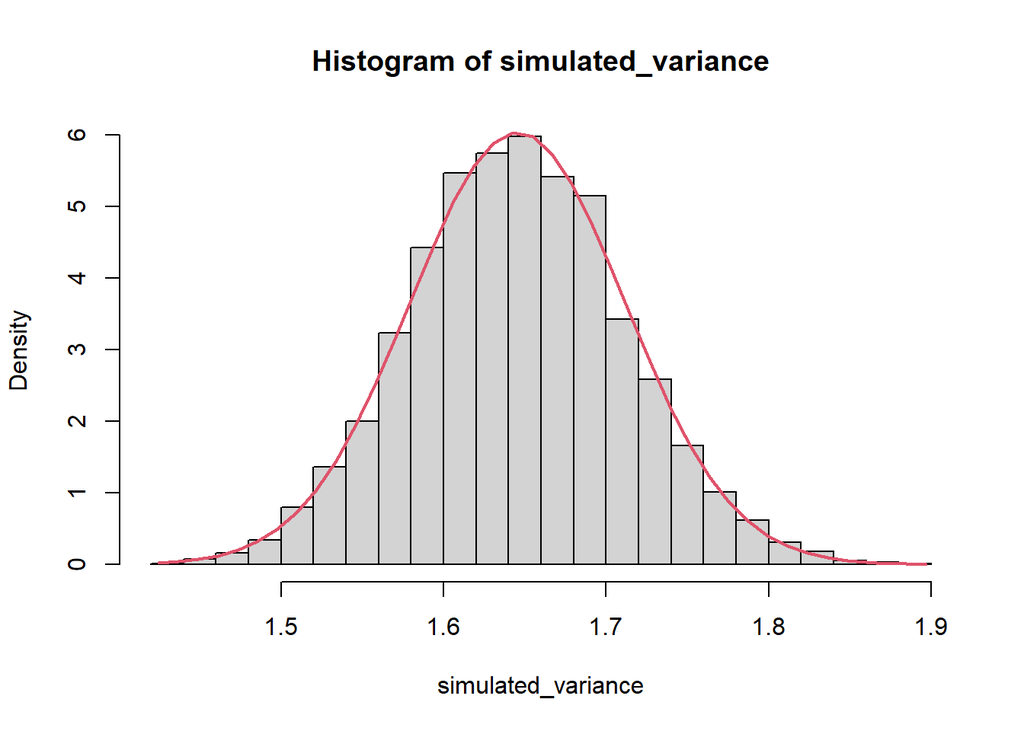

```r
nsim <- 10000
n <- length(extrapeople)
simulated_variance <- rep(0, nsim)
count <- 0
for (i in 1:nsim) {
  count <- count + 1
  x <- rpois(n = n, lambda = lambda)
  simulated_variance[count] <- var(x)
}
hist(simulated_variance, 30, freq = FALSE)
x_grid <- seq(min(simulated_variance), max(simulated_variance), length = 40)
standard_deviation <- sd(simulated_variance)
normal_curve <- dnorm(x_grid, mean = mean(simulated_variance), sd = sd(simulated_variance))
lines(x_grid, normal_curve, col = 2, lwd = 2)
```

## 2. (log)-normalmodell för elkostnad

#### 💪 Uppgift 2.1

#### 💪 Uppgift 2.2

#### 💪 Uppgift 2.3

#### 💪 Uppgift 2.4

#### 💪 Uppgift 2.5

#### 💪 Uppgift 2.6

#### 💪 Uppgift 2.7

#### 💪 Uppgift 2.8

## 3. Enkel och multipel linjär regression

#### 💪 Uppgift 3.1

#### 💪 Uppgift 3.2

#### 💪 Uppgift 3.3

#### 💪 Uppgift 3.4

#### 💪 Uppgift 3.5

#### 💪 Uppgift 3.6

#### 💪 Uppgift 3.7